# Второе занятие по R. Многоуровневая регрессия

# 1 Загрузка и установка пакетов

Сегодня нам понадобятся пакеты:

- `rio` - импортирует и экспортирует данные практически во все известные форматы
- `tidyverse` - включает много пакетов, нам нужны `dplyr` для манипуляций с данными и `ggplot2` для построения графиков
- `skimr` - описательная статистика
- `sjPlot` - красивое представление данных и результатов анализа

*Новые пакеты, которые надо установить для этого занятия:*

- `lme4` - пакет для многоуровневого моделирования
- `lmerTest` - еще один пакет для многоуровневой регрессии
- `lattice` - визуализация данных

```r
library(rio)
library(tidyverse)
library(skimr)
```

```r
library(sjPlot)
library(lme4)
library(lmerTest)
library(lattice)
```

# 2 Загрузка и подготовка данных

Воспользуемся базой данных TIMSS-2015 8 класс и подготовим переменные для работы с ними

```r
timss <- import("timss15_sci.csv")

timss$area <- as.factor(timss$area)
timss$itsex <- as.factor(timss$itsex)
timss$like_math <- as.factor(timss$like_math)
timss$par_edu <- as.factor(timss$par_edu)

timss$city <- fct_collapse(timss$area, urban = c("Urban, densely populated", "Medium size city or large town"), other = c("Suburban, on fringe of urban area", "Remote rural", "Small town or village"))

skim(timss)
```

```
## Skim summary statistics
##  n obs: 4780
##  n variables: 20
```

```
##
## Variable type: character
##       variable missing complete    n min max empty n_unique
##         bsdgsb       0     4780 4780   0  18     2        5
##       bull_scl       0     4780 4780   0  18     2      105
##  conf_math_scl       0     4780 4780   0  18     2      134
##  like_math_scl       0     4780 4780   0  18     2      136
##
## Variable type: factor
##   variable missing complete    n n_unique
##       area       0     4780 4780        5
##       city       0     4780 4780        2
##      itsex       0     4780 4780        2
##  like_math       0     4780 4780        5
##    par_edu       0     4780 4780        4
##                                top_counts ordered
##  Urb: 1558, Med: 1400, Sub: 693, Rem: 641   FALSE
##               urb: 2958, oth: 1822, NA: 0   FALSE
##               Mal: 2485, Fem: 2295, NA: 0   FALSE
##   Lik: 2295, Do : 1575, Ver: 895, Omi: 13   FALSE
##   No : 2171, Hig: 1979, Don: 602, Unk: 28   FALSE
##
## Variable type: integer
##   variable missing complete    n     mean       sd    p0       p25   p50
##    idclass       0     4780 4780 10373.66  5991.66   102   5301    10401
##   idschool       0     4780 4780   103.72    59.91     1     53      104
##     idstud       0     4780 4780 1e+06    6e+05    10201 530110.75 1e+06
##  teach_exp     107     4673 4780    23.15    11.17     1     15       25
##         p75  p100     hist
##    15702    20401 ▇▆▇▇▆▇▇▇
##      157      204 ▇▆▇▇▆▇▇▇
##  1570213.25 2e+06 ▇▆▇▇▆▇▇▇
##       32       50 ▅▃▆▆▇▇▃▁
##
## Variable type: logical
##      variable missing complete    n mean count
##  conf_sci_scl    4780        0 4780  NaN  4780
##  like_sci_scl    4780        0 4780  NaN  4780
##
## Variable type: numeric
##     variable missing complete    n   mean     sd     p0    p25    p50
##  math_achiev       0     4780 4780 538.36  78.52 298.47 483.74 541.47
##       matwgt       0     4780 4780 259.12 147.01  59.23 189.29 234.12
##   sci_achiev       0     4780 4780 544.78  72.53 305.1  496.79 548.62
##       st_age       0     4780 4780  14.76   0.42  13.25  14.5   14.75
##       totwgt       0     4780 4780 263.14 155.8   77.53 190.34 234.36
##     p75    p100     hist
##  595.46  761.34 ▁▂▅▇▇▆▂▁
##  271.05 1118.35 ▃▇▁▁▁▁▁▁
##  594.57  774.97 ▁▁▃▆▇▅▁▁
##   15      17.67 ▁▂▇▆▁▁▁▁
##  271.05 1118.35 ▅▇▁▁▁▁▁▁
```

В качестве зависимой переменной в наших моделях мы будем использовать баллы TIMSS. Для удобства интерпретации стандартизируем их, воспользовавшись формулой
$$Z = \frac{(X_{i} - \overline{X})}{\sigma_{x}}$$

```r
timss$math_achiev_sd <- (timss$math_achiev - mean(timss$math_achiev)) / sd(timss$math_achiev)

skim(timss$math_achiev_sd)
```

```
## Skim summary statistics
##
## Variable type: numeric
##              variable missing complete    n     mean sd    p0  p25  p50
##  timss$math_achiev_sd       0     4780 4780 -6.8e-16  1 -3.06 -0.7 0.04
##   p75 p100     hist
##  0.73 2.84 ▁▂▅▇▇▆▂▁
```

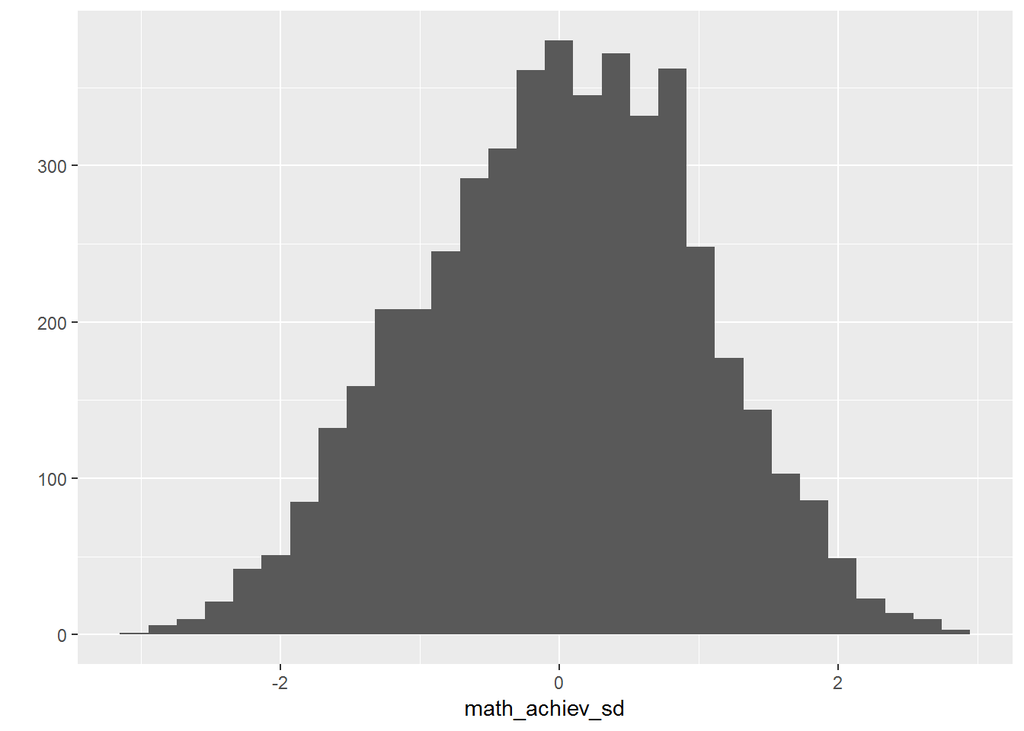

```r
qplot(data = timss, x = math_achiev_sd)
```

# 3 Регрессия: связь баллов по математике и возраста ученика

Для начала построим обычную линейную регрессию, но без независимых переменных - посмотрим только на интерцепт.

```r
supernullmodel <- lm(data = timss, math_achiev_sd ~ 1)
summary(supernullmodel)
```

```
##
## Call:
## lm(formula = math_achiev_sd ~ 1, data = timss)
##
## Residuals:
##      Min       1Q   Median       3Q      Max
## -3.05510 -0.69569  0.03956  0.72717  2.83969
##
## Coefficients:
##               Estimate Std. Error t value Pr(>|t|)
## (Intercept) -7.266e-16  1.446e-02       0        1
##
## Residual standard error: 1 on 4779 degrees of freedom
```

Какое значение интерцепта? Как выглядит такая функция? Откуда тут ошибки? Что они означают?

Теперь посмотрим на связь возраста ученика с его результатами, построив диаграмму рассеяния. Для этого воспользуемся командой `ggplot` из пакета `ggplot2`. Для этого задействуем эстетику графиков.

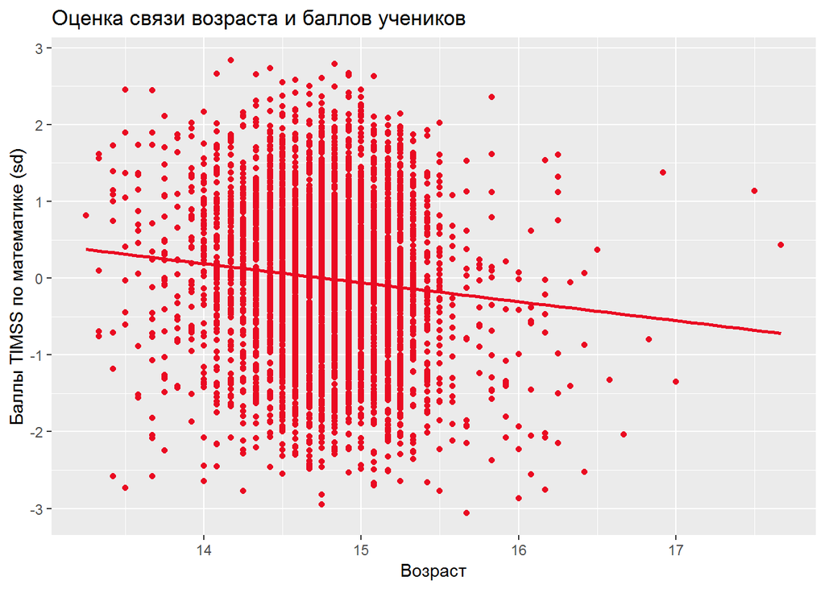

```r
# строительные леса - задаем данные и оси
  ggplot(data = timss, aes(x = st_age, y = math_achiev_sd)) +
# что мы хотим? Точки для каждого наблюдения!
  geom_point(col = "#ea0b22") +
# а еще хотим линию для линейной оценки связи
  geom_smooth(method = "lm", col = "#ea0b22", se = FALSE) +
# делаем красиво - называем оси и график
  labs(x = 'Возраст', y = 'Баллы TIMSS по математике (sd)', title = 'Оценка связи возраста и баллов учеников')
```

Каково направление связи? Как вы думаете, почему?

Теперь посмотрим, различается ли эта связь в разных классах - построим отдельные линии линейной оценки для каждого класса. Для этого добавим в эстетику ggplot еще один параметр - переменную группировки idclass.

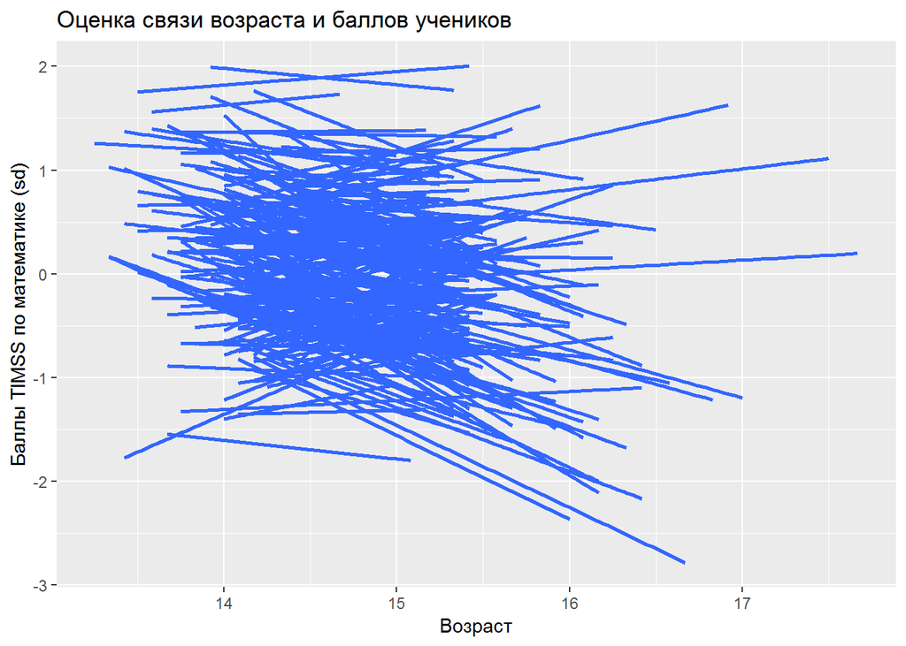

```r
ggplot(data = timss, aes(x = st_age, y = math_achiev_sd, group = idclass)) +
  geom_smooth(method = "lm", se = FALSE) +
  labs(x = 'Возраст', y = 'Баллы TIMSS по математике (sd)', title = 'Оценка связи возраста и баллов учеников')
```

Каково направление связи? Одинаково ли оно для всех групп? Одинаков ли интерцепт в разных группах?

Попробуем предположить, за счет чего можно объяснить различия. Предположим, что в городах скорее отрицательная связь (чем же они там занимались,раз не учились?), а в остальных населенных пунктах - положительная. Для проверки этого предположения добавим в график еще один параметр - цвет линий.

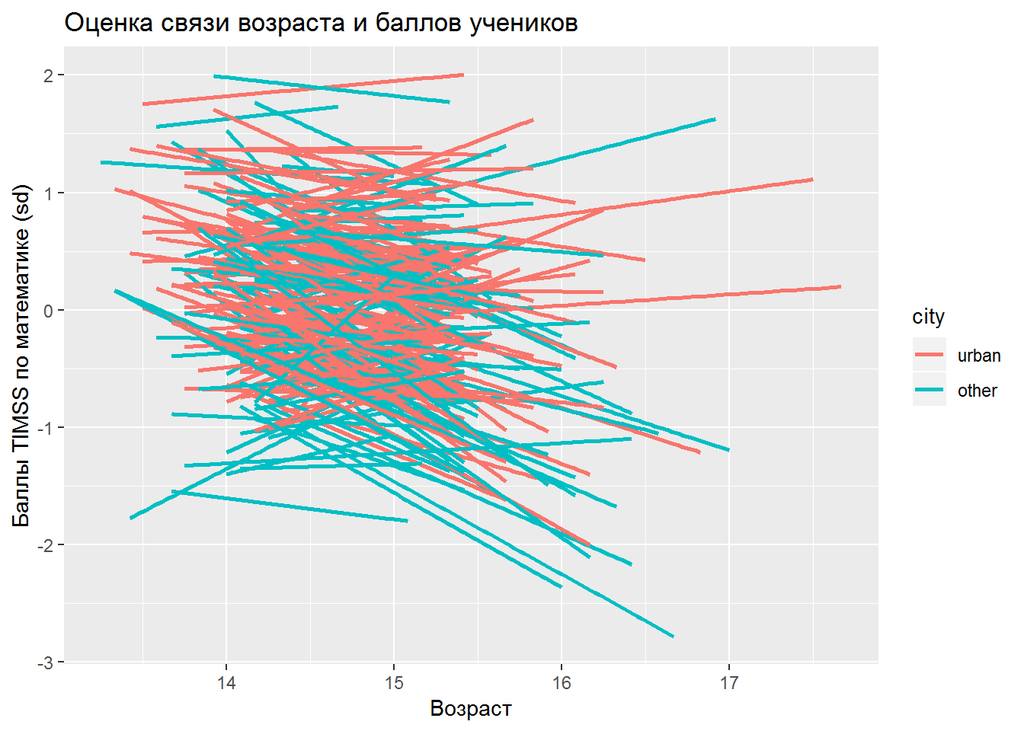

```r
ggplot(data = timss, aes(x = st_age, y = math_achiev_sd, group = idclass, color = city)) +
  geom_smooth(method = "lm", se = FALSE) +
  labs(x = 'Возраст', y = 'Баллы TIMSS по математике (sd)', title = 'Оценка связи возраста и баллов учеников')
```

Как вы думаете, нужно ли делать многоуровневую регрессию? Почему?

# 4 Многоуровневая регрессия

[output not shown]

## 4.1 Base model

Итак, оценим нулевую (базовую) модель, где варьируется только интерцепт.

```r
nullmodel <- lmer(data = timss, math_achiev_sd ~ (1 | idclass), REML = FALSE)
summary(nullmodel)
```

```
## Linear mixed model fit by maximum likelihood . t-tests use
##   Satterthwaite's method [lmerModLmerTest]
## Formula: math_achiev_sd ~ (1 | idclass)
##    Data: timss
##
##      AIC      BIC   logLik deviance df.resid
##  11742.0  11761.4  -5868.0  11736.0     4777
##
## Scaled residuals:
##     Min      1Q  Median      3Q     Max
## -3.1701 -0.6686  0.0106  0.6736  3.8193
##
## Random effects:
##  Groups   Name        Variance Std.Dev.
##  idclass  (Intercept) 0.3982   0.6310
##  Residual             0.6028   0.7764
## Number of obs: 4780, groups:  idclass, 221
##
## Fixed effects:
##               Estimate Std. Error         df t value Pr(>|t|)
## (Intercept)  -0.003243   0.044146 221.006941  -0.073    0.942
```

Сравним с линейной регрессионной моделью, которую оценивали в самом начале.

```r
summary(supernullmodel)
```

```
##
## Call:
## lm(formula = math_achiev_sd ~ 1, data = timss)
##
## Residuals:
##      Min       1Q   Median       3Q      Max
## -3.05510 -0.69569  0.03956  0.72717  2.83969
##
## Coefficients:
##               Estimate Std. Error t value Pr(>|t|)
## (Intercept) -7.266e-16  1.446e-02       0        1
##
## Residual standard error: 1 on 4779 degrees of freedom
```

Различаются ли фиксированные интерцепты в каждой модели?

Сравним модели с использованием статистики максимального правдоподобия

```r
logLik(nullmodel)
```

```
## 'log Lik.' -5867.988 (df=3)
```

```r
logLik(supernullmodel)
```

```
## 'log Lik.' -6782.026 (df=2)
```

Какая модель подходит данным лучше?

Обратимся к базовой модели. Мы можем посмотреть отдельно на фиксированную и рандомную часть уравнения, воспользовавшись командами `fixef` и `ranef`.

```r
fixef(nullmodel)
```

```
##  (Intercept)
## -0.003243007
```

```r
ranef(nullmodel)
```

```
## $idclass
##        (Intercept)
## 102   -0.479680362
## 201    0.645906144
## 203   -0.461904660
## 301   -0.550653068
## 401    0.313836454
## 502   -0.609759680
## 601    0.393626877
## 603    0.347524595
## 701   -0.233719464
## 801   -0.041334353
## 901    0.724648936
## 1002  -0.445953614
## 1101   0.173370259
```

[output cut: 208 more lines]

Варьирующуюся (рандомную) часть для каждого класса мы можем визуализировать с помощью команды `qqmath` из пакета `lattice`.

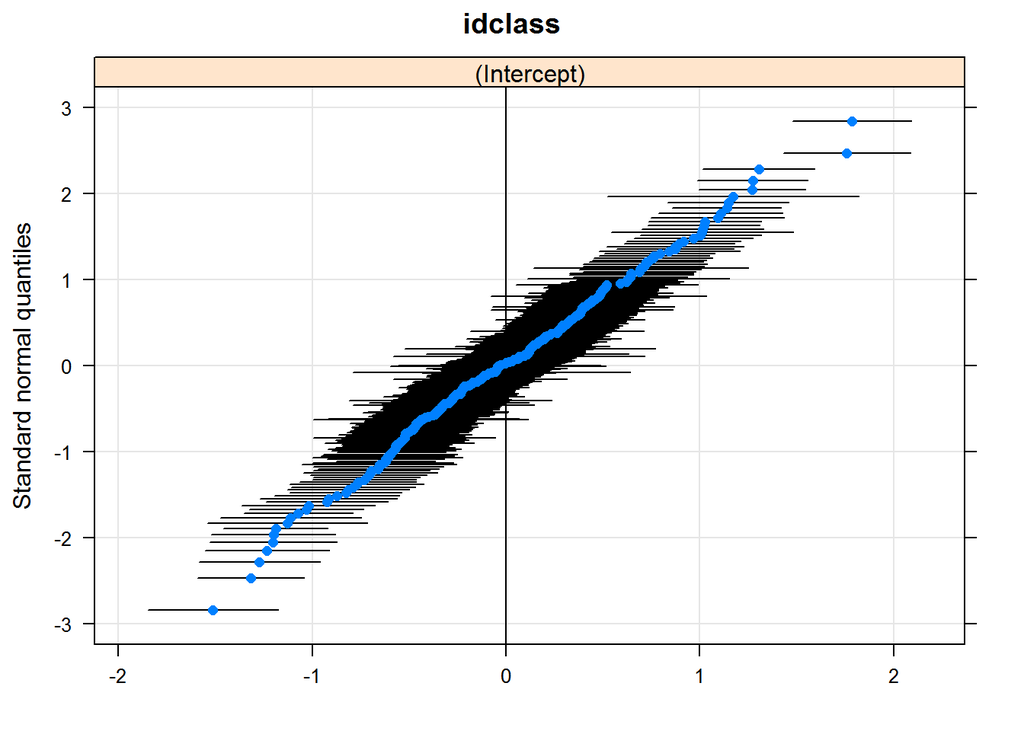

```r
qqmath(ranef(nullmodel, condVar = TRUE))
```

Что на осях X и Y? О чем говорит этот график?

## 4.2 Random intercept

Добавим в модель независимую переменную первого уровня - возраст ученика. Для начала оценим модель fixed slope, random intercept.

```r
rifs <- lmer(data = timss, math_achiev_sd ~ st_age +  (1 | idclass), REML = FALSE)
summary(rifs)
```

```
## Linear mixed model fit by maximum likelihood . t-tests use
##   Satterthwaite's method [lmerModLmerTest]
## Formula: math_achiev_sd ~ st_age + (1 | idclass)
##    Data: timss
##
##      AIC      BIC   logLik deviance df.resid
##  11682.2  11708.0  -5837.1  11674.2     4776
##
## Scaled residuals:
##     Min      1Q  Median      3Q     Max
## -3.1722 -0.6700  0.0073  0.6660  3.7823
##
## Random effects:
##  Groups   Name        Variance Std.Dev.
##  idclass  (Intercept) 0.3952   0.6287
##  Residual             0.5949   0.7713
## Number of obs: 4780, groups:  idclass, 221
##
## Fixed effects:
##               Estimate Std. Error         df t value Pr(>|t|)
## (Intercept)    3.31822    0.42333 4723.01525   7.838 5.60e-15 ***
## st_age        -0.22507    0.02853 4660.98122  -7.889 3.78e-15 ***
## ---
## Signif. codes:  0 '***' 0.001 '**' 0.01 '*' 0.05 '.' 0.1 ' ' 1
##
## Correlation of Fixed Effects:
##        (Intr)
## st_age -0.995
```

Что относится к random effects? Fixed? Какова связь возраста ученика с его баллом в TIMSS?

Попробуем визуализировать получившиеся результаты. Для этого сначала мы вычислим предсказанные моделью значения зависимой переменной, а затем построим график с получившимися значениями.

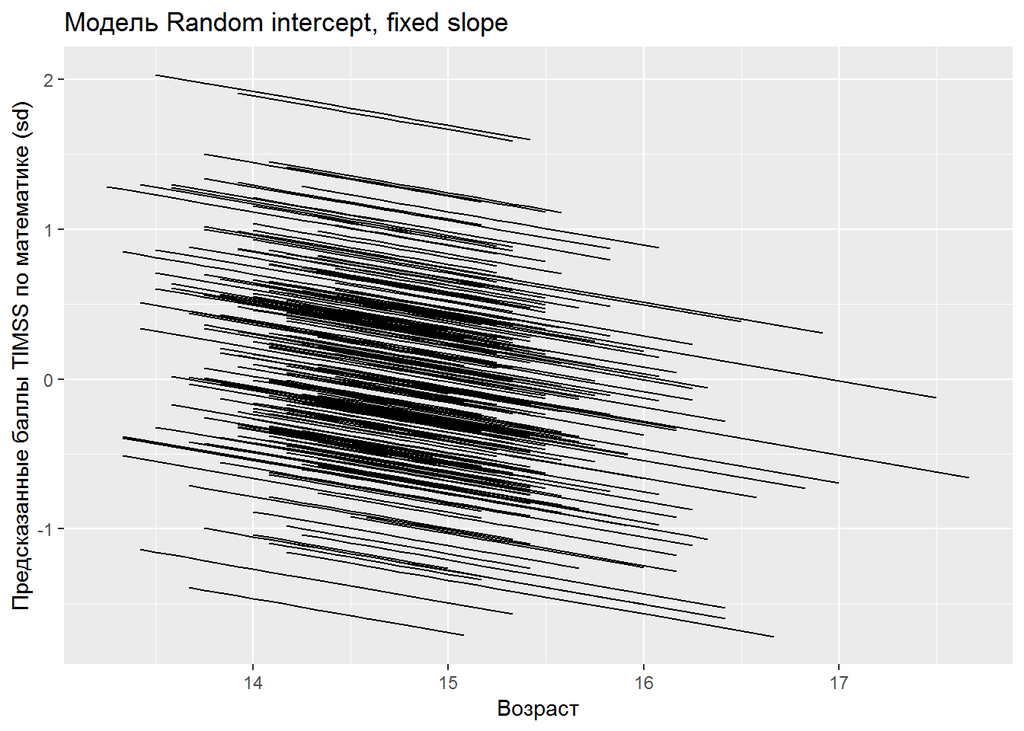

```r
timss$pred_math <- fitted(rifs)

ggplot(timss, aes(x=st_age, y = pred_math, group=idclass))  +
    geom_line() +
    labs(x = 'Возраст', y = 'Предсказанные баллы TIMSS по математике (sd)', title = 'Модель Random intercept, fixed slope')
```

## 4.3 Random slope random intercept - uncorrelated

Теперь позволим меняться и интерцепту, и углу наклона - оценим модель Random slope, random intercept. Для начала оценим модель с *некоррелирующими* slope и intercept

```r
rirsu <- lmer(data = timss, math_achiev_sd ~ st_age +  (st_age || idclass), REML = FALSE)
```

```
## singular fit
```

```r
summary(rirsu)
```

```
## Linear mixed model fit by maximum likelihood . t-tests use
##   Satterthwaite's method [lmerModLmerTest]
## Formula: math_achiev_sd ~ st_age + (st_age || idclass)
##    Data: timss
##
##      AIC      BIC   logLik deviance df.resid
##  11679.7  11712.0  -5834.8  11669.7     4775
##
## Scaled residuals:
##     Min      1Q  Median      3Q     Max
## -3.2023 -0.6680  0.0113  0.6666  3.7803
##
## Random effects:
##  Groups    Name        Variance  Std.Dev.
##  idclass   (Intercept) 6.475e-13 8.047e-07
##  idclass.1 st_age      1.831e-03 4.279e-02
##  Residual              5.940e-01 7.707e-01
## Number of obs: 4780, groups:  idclass, 221
##
## Fixed effects:
##               Estimate Std. Error         df t value Pr(>|t|)
## (Intercept)    3.30436    0.42086 4661.57625   7.851 5.07e-15 ***
## st_age        -0.22411    0.02866 4725.79650  -7.820 6.46e-15 ***
## ---
## Signif. codes:  0 '***' 0.001 '**' 0.01 '*' 0.05 '.' 0.1 ' ' 1
##
## Correlation of Fixed Effects:
##        (Intr)
## st_age -0.995
## convergence code: 0
## singular fit
```

Что относится к random effects? Fixed? Какова связь возраста ученика с его баллом в TIMSS?

Визуализируем и эту модель

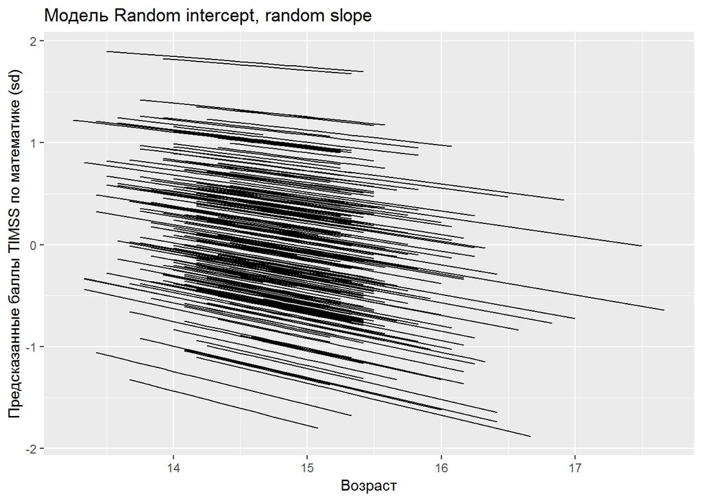

```r
timss$pred_math2 <- fitted(rirsu)

  ggplot(timss, aes(x=st_age, y = pred_math2, group=idclass))  +
  geom_line() +
  labs(x = 'Возраст', y = 'Предсказанные баллы TIMSS по математике (sd)', title = 'Модель Random intercept, random slope')
```

Что изменилось?

Проверим, есть ли основания полагать, что наши slope и intercept коррелируют. Для этого построим самый простой график

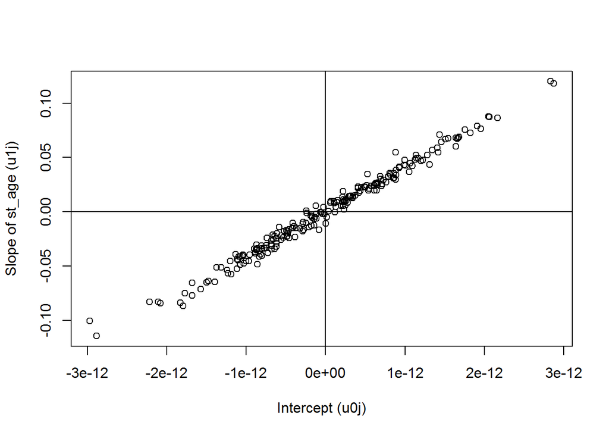

```
## integer(0)
```

```r
ref_rirsu <- ranef(rirsu, condVar = TRUE)

plot(ref_rirsu[[1]], xlab = "Intercept (u0j)", ylab = "Slope of st_age (u1j)") + abline(h = 0) + abline(v = 0)
```

Как будто бы коррелируют! Бежим смотреть меодель с корреляцией!

## 4.4 Random slope random intercept - correlated

Итак, попросим R учитывать, что наши slope и intercept коррелируют

```r
rirsc <- lmer(data = timss, math_achiev_sd ~ st_age +  (st_age | idclass), REML = FALSE)
summary(rirsc)
```

```
## Linear mixed model fit by maximum likelihood . t-tests use
##   Satterthwaite's method [lmerModLmerTest]
## Formula: math_achiev_sd ~ st_age + (st_age | idclass)
##    Data: timss
##
##      AIC      BIC   logLik deviance df.resid
##  11677.1  11715.9  -5832.5  11665.1     4774
##
## Scaled residuals:
##     Min      1Q  Median      3Q     Max
## -3.1308 -0.6638  0.0105  0.6644  3.7712
##
## Random effects:
##  Groups   Name        Variance Std.Dev. Corr
##  idclass  (Intercept) 6.53053  2.5555
##           st_age      0.03301  0.1817   -0.97
##  Residual             0.58945  0.7678
## Number of obs: 4780, groups:  idclass, 221
##
## Fixed effects:
##             Estimate Std. Error       df t value Pr(>|t|)
## (Intercept)   3.2673     0.4617 218.3082   7.076 1.99e-11 ***
## st_age       -0.2215     0.0315 221.2379  -7.033 2.49e-11 ***
## ---
## Signif. codes:  0 '***' 0.001 '**' 0.01 '*' 0.05 '.' 0.1 ' ' 1
##
## Correlation of Fixed Effects:
##        (Intr)
## st_age -0.996
```

Что относится к random effects? Fixed? Какова связь возраста ученика с его баллом в TIMSS? Какова корреляция random effects?

Визуализируем и эту модель

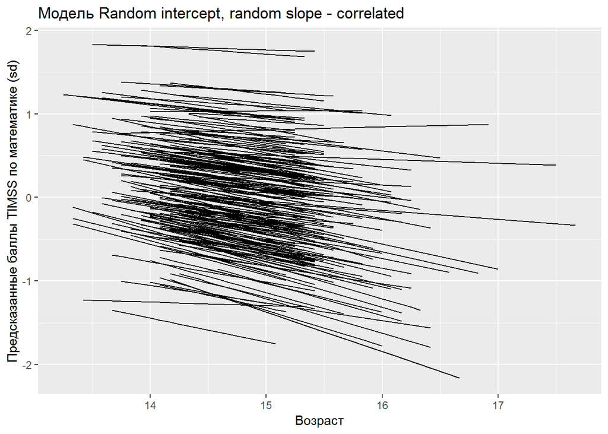

```r
timss$pred_math3 = fitted(rirsc)

ggplot(timss, aes(x=st_age, y = pred_math3, group=idclass))  +
  geom_line()  +
  labs(x = 'Возраст', y = 'Предсказанные баллы TIMSS по математике (sd)', title = 'Модель Random intercept, random slope - correlated')
```

Визуализируем также обе рандомные части

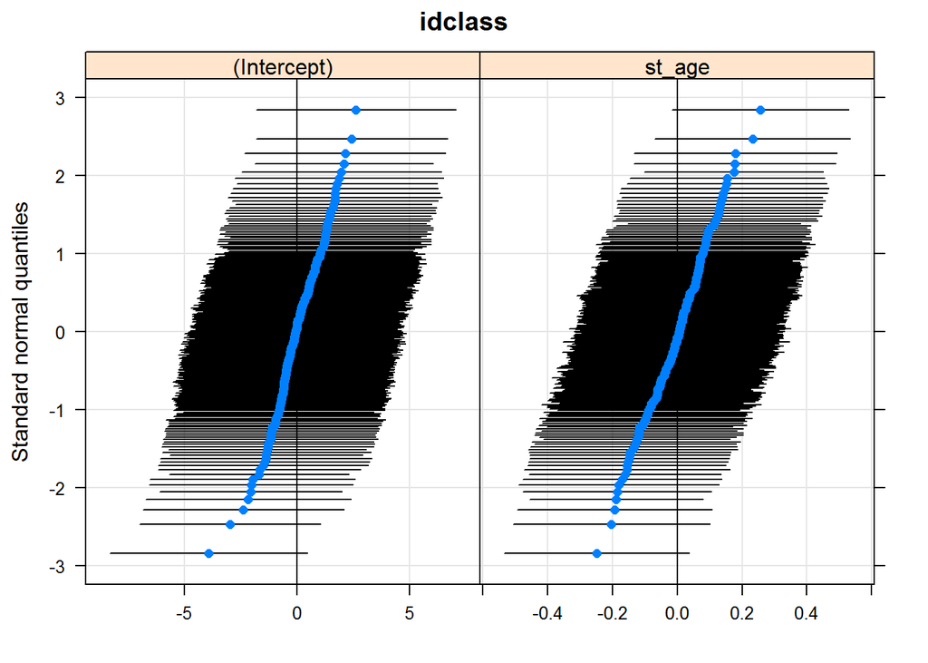

```r
qqmath(ranef(rirsc, condVar = TRUE))
```

Сравним модели. Какая лучше подходит данным?

```r
anova(rirsu, rirsc)
```

```
## Data: timss
## Models:
## rirsu: math_achiev_sd ~ st_age + (st_age || idclass)
## rirsc: math_achiev_sd ~ st_age + (st_age | idclass)
##       Df   AIC   BIC  logLik deviance  Chisq Chi Df Pr(>Chisq)
## rirsu  5 11680 11712 -5834.8    11670
## rirsc  6 11677 11716 -5832.5    11665 4.5965      1    0.03204 *
## ---
## Signif. codes:  0 '***' 0.001 '**' 0.01 '*' 0.05 '.' 0.1 ' ' 1
```